# Supplementary Information for:

A simplified dynamic bioenergetic model for coral-*Symbiodinium* symbioses and coral bleaching as an alternate stable state

Ross Cunning, Erik B. Muller, Ruth D. Gates, Roger M. Nisbet

This supplement provides justification and derivations from the literature for all parameter values used in the model, as well as additional figures that demonstrate the structure and behavior of the model and its specific components.

# Model parameters

All parameters in the model are listed here along with the relevant literature that provides a basis for the value used. In most cases, the units of the values reported in the literature were converted to units appropriate for the model, which was accomplished using a consistent set of stoichiometric conversion factors also based on reported literature (see Conversion factors used in parameter derivation). Calculations executed in R are shown for each parameter (when relevant) as well as the final value used.

## Parameter value derivations

#### $n_{NH}$: N:C molar ratio in host biomass

Horwitz et al. (2015) measured a molar C:N ratio of 5.53 in anemones under control conditions, which converts to:

```r
1 / 5.53
```

*0.1808* N:C ratio (dimensionless)

#### $n_{NS}$: N:C molar ratio in symbiont biomass

This value should approximate the Redfield ratio (following Muller et al. (2009)).  
*0.13* N:C ratio (dimensionless)

#### $n_{NX}$: N:C molar ratio in prey biomass

Assuming the coral feeds primarily on zooplankton, a general heterotroph has a molar N:C ratio of 0.2 (Muller et al. 2009).  
*0.2* N:C ratio (dimensionless)

#### $j_{HT}^0$: Specific turnover rate of host biomass

Jacobson, Edmunds, and Muller (2016) parameterized a DEB model for coral symbiosis, and reported a specific maintenance rate of 0.03 mol C<sub>E</sub> mol C<sub>V</sub><sup>-1</sup> d<sup>-1</sup>, where subscripts E and V refer to reserve and structural biomass. We assume (simplistically) the same rate per unit of total biomass: *0.03* C-mol H C-mol H<sup>-1</sup> d<sup>-1</sup>

#### $j_{ST}^0$: Specific turnover rate of symbiont biomass

Values of *Symbiodinium* and other dinoflagellate respiration rates may provide a reasonable approximation of the specific turnover rate of symbiont biomass, yet values calculated from various studies range widely from 0.01 to nearly 0.2. Without data for a more confident estimation of this parameter, we choose a value at the low end of this range, since 0.2 seems unrealistic and many rates may be depressed in symbiotic dinoflagellates relative to their free-living counterparts. *0.03* C-mol S C-mol S<sup>-1</sup> d<sup>-1</sup>

#### $\sigma_{NH}, \sigma_{NS}$: Proportions of nitrogen recycled from host and symbiont biomass turnover

Assume highly efficient recycling by both symbiont and host to avoid loss to the environment:  
*0.9* and *0.9* (dimensionless)

#### $\sigma_{CS}$: Proportion of metabolic CO<sub>2</sub> produced by symbiont recycled passively to photosynthesis

Assume that CO<sub>2</sub> produced within symbiont cells is recycled with high efficiency, potentially aided by symbiont carbon concentrating mechanisms.  
*0.9* (dimensionless)

#### $\sigma_{CH}$: Proportion of metabolic CO<sub>2</sub> produced by host recycled passively to photosynthesis

Assume that most metabolic CO<sub>2</sub> produced within host cells rapidly converts to HCO<sub>3</sub><sup>-</sup> at intracellular pH ~ 7.2 (Venn et al. 2009), and that only ~10% actually remains as CO<sub>2</sub> (Zeebe and Wolf-Gladrow 2001) that could diffusively supply photosynthesis. This passive supply is differentiated from all active host carbon concentrating mechanisms (CCMs) that facilitate CO<sub>2</sub> supply to photosynthesis, which are separately treated collectively as the $jCO~2~$ flux.  
*0.1* (dimensionless)

#### $j_{Xm}$: Maximum specific rate of assimilation from host feeding

Wijgerde et al. (2011) measured depletion of carbon from captured prey in *Galaxea fascicularis* (including both intracoelenteric and extracoelenteric feeding), reporting a maximum specific carbon assimilation rate of 77.6 µgC cm<sup>-2</sup> 6h<sup>-1</sup>.

```r
77.6 / µg.g / gC.molC * cm2.m2 / CmolR.m2_Gfas * 24/6
```

*0.1292* C-mol X C-mol H<sup>-1</sup> d<sup>-1</sup>

#### $K_X$: Half-saturation constant of assimilation from host feeding

For consistency, and due to a lack of available data, we use the same value as Muller et al. (2009).

```r
1e-6
```

*1e-06* C-mol X L<sup>-1</sup>

#### $j_{Nm}$: Maximum specific DIN uptake rate by host

Muscatine and D’Elia (1978) measured ammonium uptake in 3 coral species and reported an average value of 7.22 µmol NH<sub>4</sub><sup>+</sup>-N mg chl *a*<sup>-1</sup> h<sup>-1</sup> (Table 1, uncorrected), which converts to:

```r
7.22 * h.d * nmolchlA.cm2 * gchlA.molchlA * mg.g / nmol.mol / CmolR.m2_Spis * cm2.m2 / µmol.mol
```

*0.02493* mol N C-mol H<sup>-1</sup> d<sup>-1</sup>  
Hoegh-Guldberg and Williamson (1999) measured ammonium and dissolved free amino acid uptake in *Pocillopora damicornis* and reported a maximum rate of 91.8 nmol N cm<sup>-2</sup> h<sup>-1</sup>, which converts to:

```r
91.8 * h.d * cm2.m2 / CmolR.m2_Spis / nmol.mol
```

[output not shown]

```r
3.5 * h.d * 22 / CmolR.m2_Spis * cm2.m2 / µmol.mol / 1000
```

*0.0308* mol N C-mol H<sup>-1</sup> d<sup>-1</sup>  
Godinot, Grover, et al. (2011) measured ammonium uptake kinetics in *Stylophora pistillata* and reported a maximum rate of 5.42 molN mg chl<sup>-1</sup> h<sup>-1</sup>, which converts to:

```r
5.42 * h.d * µgchl.cm2_Spis / CmolR.m2_Spis * cm2.m2 / µmol.mol / 1000
```

*0.0477* mol N C-mol H<sup>-1</sup> d<sup>-1</sup>  
Averaging these reported values, we arrive at:  
*0.035* mol N C-mol H<sup>-1</sup> d<sup>-1</sup>

#### $K_N$: Half-saturation constant for DIN uptake by host

Muscatine and D’Elia (1978) measured ammonium uptake in 3 coral species and reported an average half-saturation constant of 1.84 µmolN L<sup>-1</sup> (Table 1, uncorrected).  
Godinot, Grover, et al. (2011) measured ammoinum uptake kinetics in *Stylophora pistillata* and reported a half-saturation constant of 0.46 µmol N L<sup>-1</sup>.  
Averaging these reported values (weighted by number of species measured), we arrive at:

```r
(1.84*3 + 0.46*1)/4
```

*1.495* mol N L<sup>-1</sup>

#### $k_{CO_2}$: Efficacy of CO<sub>2</sub> delivery by host CCMs

This parameter represents the relative amount of CO<sub>2</sub> that can be delivered by the host to photosynthesis given the reducing power generated from 1 mol of fixed carbon. We assume that the host uses a portion of its fixed carbon to generate ATP which is then used to activate a variety of carbon concentrating mechanisms (see Wooldridge (2013)). We assume these CCMs are efficient and can deliver an order of magnitude more CO<sub>2</sub> relative to the fixed carbon available.  
*10* mol CO<sub>2</sub> mol C<sup>-1</sup>

#### $j_{HGm}$: Maximum specific growth rate of host

We set this to a high value such that constraints on growth are primarily determined by substrate availabilities rather than the maximum value.  
*1* C-mol H C-mol H<sup>-1</sup> d<sup>-1</sup>

#### $y_{CL}$: Quantum yield of photosynthesis

The maximum theoretical quantum yield is 0.125 mol C fixed per mol photons. Brodersen et al. (2014) presented a balanced light budget based on microenvironmental photobiology of *Montastrea curta*, and reported a quantum yield of 0.102 O<sub>2</sub> photon<sup>-1</sup>.  
*0.1* mol C mol photons<sup>-1</sup>

#### $y_{C}$: Yield of biomass formation from photosynthate

This coefficient specifies the efficiency of conversion of photosynthate into biomass at the biomass synthesizing units, which combine photosynthate (CH<sub>2</sub>O), ammonia (NH<sub>3</sub>) and O<sub>2</sub> to form biomass, water, and CO<sub>2</sub>. In order to balance this macrochemical equation, there must be a carbon loss, which is accounted for using $y_{C}$ < 1. We take a value of 0.8 following Muller et al. (2009). *0.8* C-mol mol C<sup>-1</sup>

Following this macrochemical equation, the amount of CO<sub>2</sub> produced during biomass formation can be specified as $(1-y_C)j_P/y_C$, where j_P is the production flux of the SU (see equations 13 and 14 in the main text).

#### $\bar{a}^*$: Effective light-absorbing cross-section of symbiont

Hennige et al. (2009) measured spectra-weighted absoprtion coefficients from 400 to 700nm *ā**<sub>(400-700)</sub> for eight *Symbiodinium* types in culture at two different light levels, and reported a (grand mean) value of 0.01095 m<sup>2</sup> mg chl *a*<sup>-1</sup> [from Table 6]. This converts to:

```r
0.01095 * mg.g * gchlA.gC * gC.molC
```

*1.342* m<sup>2</sup> C-mol S<sup>-1</sup>

#### $k_{NPQ}$: Capacity of non-photochemical quenching

Gorbunov et al. (2001) report that the capacity of non-photochemical quenching is approximately 4 times the capacity of photochemistry on a sunny day. Therefore, we take the maximum relative capacity of NPQ to be 4 times the maximum rate of photochemical quenching ($j_{CPm}$; see below), giving a value of:

```r
defpars$jCPm / defpars$yCL * 4
```

*112* mol photons C-mol S<sup>-1</sup> d<sup>-1</sup>

#### $j_{CPm}$: Maximum specific photosynthesis rate of symbiont

In theory, this value should be the maximum carboxylation rate of *Symbiodinium* Rubisco (RuBP). Leggat, Whitney, and Yellowlees (2004) report a maximum carboxylation rate at 29°C of 140 CO<sub>2</sub> RuBP<sup>-1</sup> s<sup>-1</sup> [Max. value, p. 143], which converts to:

```r
140 * s.h * h.d * RuBP.CmolS
```

*2.794* mol C C-mol S<sup>-1</sup> d<sup>-1</sup>

#### $j_{SGm}$: Maximum specific growth rate of symbiont

We use the maximum specific growth rate of *Symbiodinium* that is reported by Chang, Prézelin, and Trench (1983)  
*0.25* C-mol S C-mol S<sup>-1</sup> d<sup>-1</sup>

#### $b$: Scaling parameter for strength of bleaching response

This value determines the magnitude of symbiont biomass loss (considered as expulsion of symbionts during bleaching) in response to ROS. In this context, relative ROS concentrations are assumed to trigger symbiont expulsion via unknown signaling mechanisms. Larger values of this parameter cause greater biomass loss in response to ROS signaling (i.e., a more severe bleaching response). Since this represents symbionts being expelled from the system, we use a value about two orders of magnitude higher than the turnover rate due to maintenance. *5* (dimensionless)

## Conversion factors used in parameter derivation

```r
# Conversion values used in parameter value calculations
CmolR.m2 <- 3.8  # Edmunds et al. 2011
cm2.m2 <- 10000
mg.g <- 1000
h.d <- 24
s.h <- 3600
min.d <- 1440
cm2.m2 <- 10000
RuBP.CmolS <- 2.31e-7  # Brading et al. 2013
nmol.mol <- 1e9
mmol.mol <- 1e3
µmol.mol <- 1e6
CmolS.µm3 <- 2.29144e-14  # Brading et al. 2011
mm3.µm3 <- 1e-9
gchlA.CmolS <- 0.111  # Brading et al. 2013
gC.molC <- 12.011
mg.g <- 1000
µg.g <- 1e6
pg.g <- 1e12
gchlA.gC <- 0.01020408  # Brading et al. 2013
gchlA.molchlA <- 893.5
CmolR.m2_Spis <- 0.6  # Muscatine et al. 1989 in Edmunds et al. 2011 -- also 0.5 in Grover 2002
nmolchlA.cm2 <- 9.66  # Edmunds et al. 2011
µgchl.cm2_Spis <- 22  # Godinot et al. 2011 PLoS ONE
CmolR.m2_Gfas <- 2  # Schutter et al. 2010 [based on reported 6 mg afdw cm-2 (Fig. 9) and 41.4% Carbon by weight (Results section)]
gC.artemia <- 0.678e-6  # Wijgerde et al. 2011 JEB
pgC.cellS <- 234.5 # Average of two clade A phylotypes in Brading et al. 2013
CmolS.cellS <- pgC.cellS / pg.g / gC.molC
```

# Figure S1

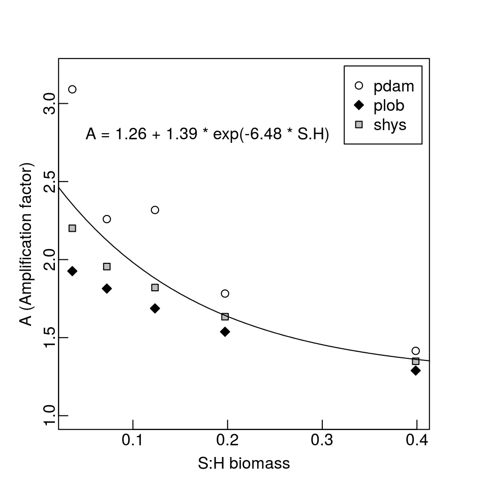

**Fig. S1. Light amplification and self-shading.** The amplification factor (A) is the ratio of internal scalar irradiance experienced by *Symbiodinium* to the external downwelling irradiance, and is greater than 1 due to multiple scattering of incident light by the coral skeleton. The amplification factor decreases as a function of symbiont abundance (converted to symbiont to host biomass ratio) due to self-shading. Data are from Marcelino et al. (2013) using skeletons from three different coral species: pdam=*Pocillopora damicornis*; plob=*Porites lobata*; shys=*Seriatopora hystrix*.

# Figure S2

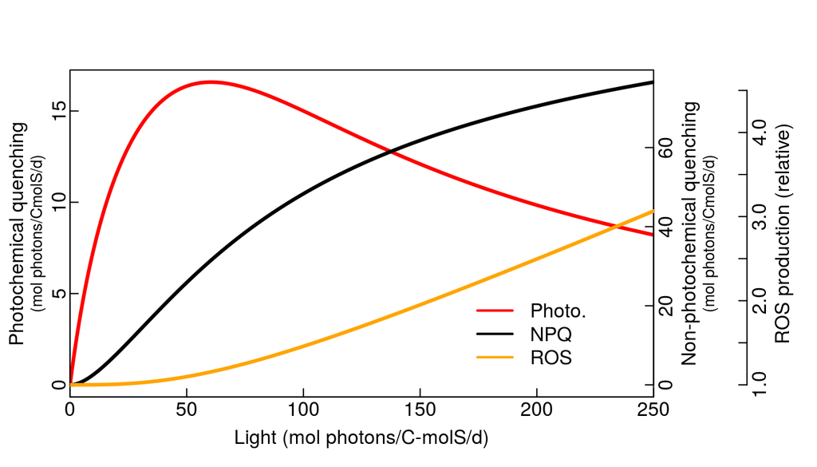

**Fig. S2. Photosynthesis-Irradiance curves of modeled symbiont.** The rates of light energy quenching through photochemistry (red line) and non-photochemical quenching (black line), and the relative production of reactive oxygen species (orange line) are plotted as a function of the scalar irradiance experienced by the symbiont (note different y-axes for each line). These curves represent the behavior of the photosynthesis SU independent of the host and without CO<sub>2</sub> limitation of photosynthesis (*j<sub>CO2</sub>* set to a very high value). The structure of the photosynthesis SU, with the negative feedback between excess light and photosynthesis rate, produces the classic shape of a P-I curve demonstrating photoinhibition, suggesting the mechanism is robust.

# Figure S3

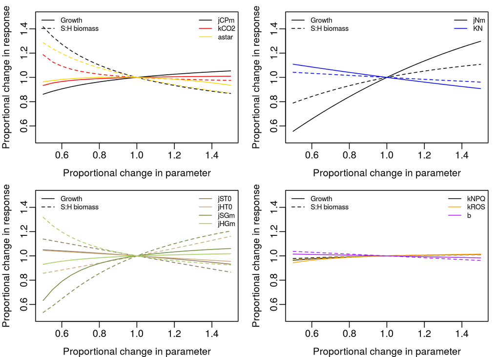

**Fig. S3. Sensitivity analysis under high DIN (4e-6 M) and intermediate light (20 mol m<sup>-2</sup> d<sup>-1</sup>).** See Fig. 4 in main text.

# Figure S4

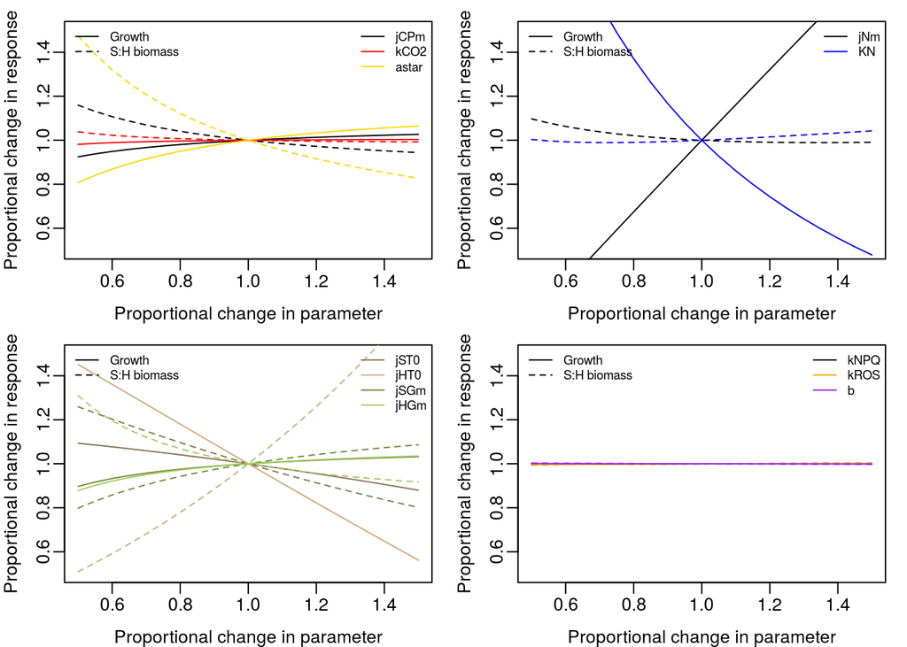

**Sensitivity analysis under low DIN (1e-7 M) and low light (5 mol m<sup>-2</sup> d<sup>-1</sup>).** See Fig. 4 in main text.

# Figure S5

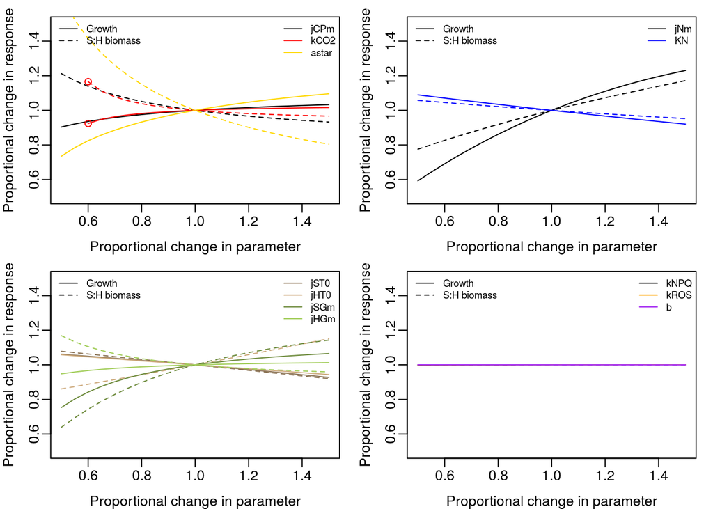

**Fig. S5. Sensitivity analysis under high DIN (4e-6 M) and low light (5 mol m<sup>-2</sup> d<sup>-1</sup>).** See Fig. 4 in main text.

# Figure S6

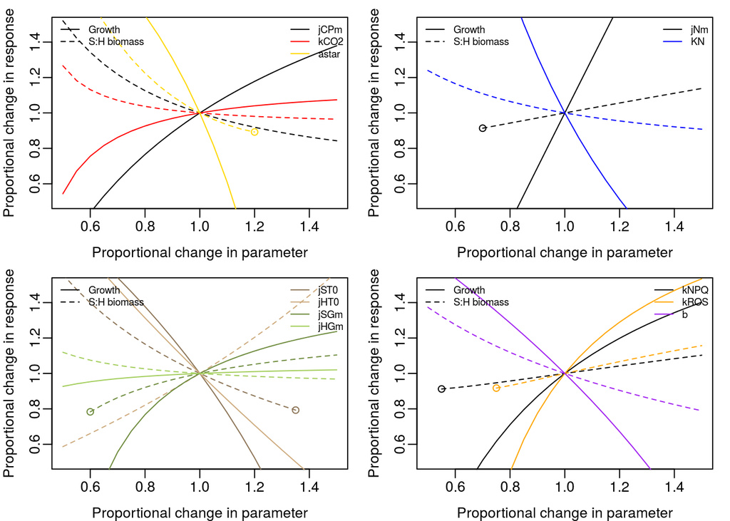

**Fig. S6. Sensitivity analysis under low DIN (1e-7 M) and high light (30 mol m<sup>-2</sup> d<sup>-1</sup>).** See Fig. 4 in main text.

# Figure S7

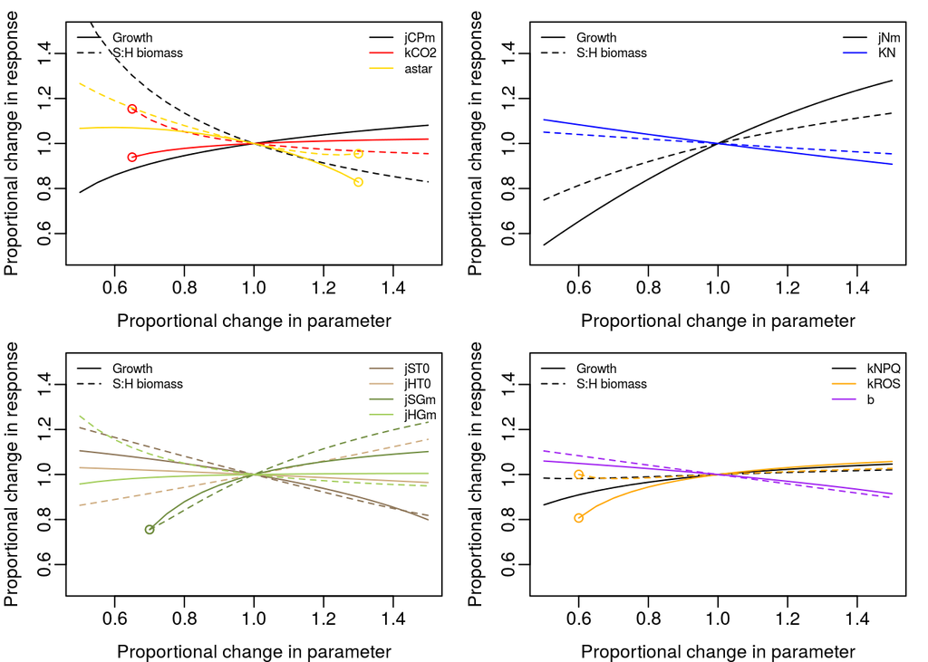

**Fig. S7. Sensitivity analysis under high DIN (4e-6 M) and high light (30 mol m<sup>-2</sup> d<sup>-1</sup>).** See Fig. 4 in main text.

# Figure S8

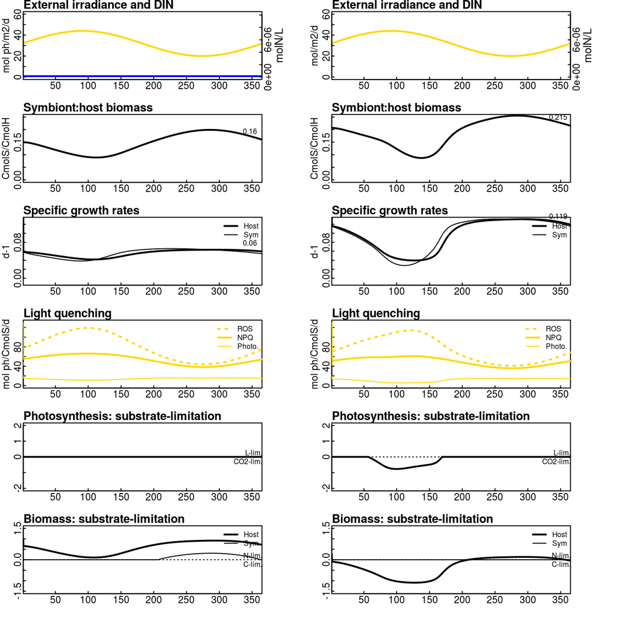

**Fig. S8. Full system dynamics of seasonal light variation at two nutrient levels.** This figure accompanies Figure 5 in the main text, and shows additional model fluxes that demonstrate the mechanisms underlying the changes in the system state in these simulations.

# Figure S9

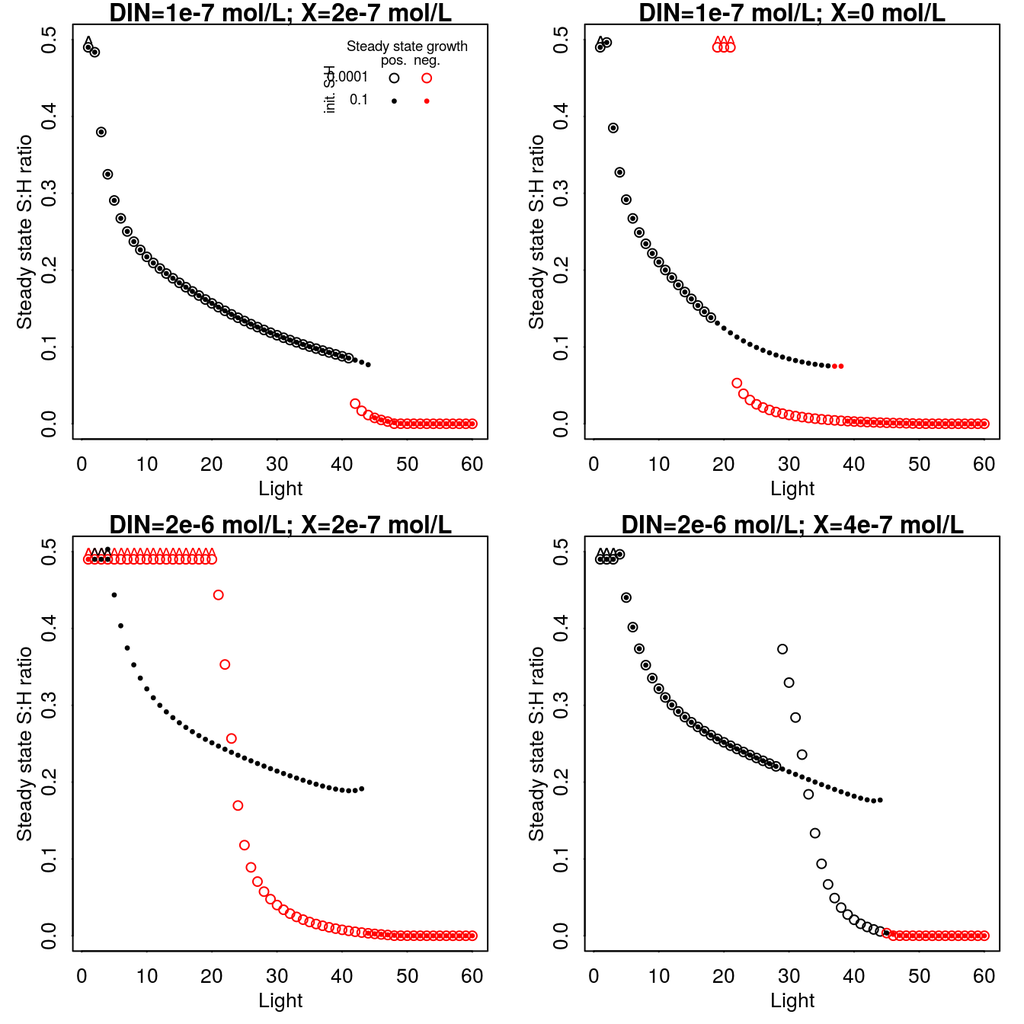

# References

Brodersen, Kasper Elgetti, Mads Lichtenberg, Peter J Ralph, Michael Kühl, and Daniel Wangpraseurt. 2014. “Radiative energy budget reveals high photosynthetic efficiency in symbiont-bearing corals.” *Journal of The …* 11 (93). The Royal Society: 20130997–7. doi:10.1098/rsif.2013.0997.

Chang, S S, Barbara B Prézelin, and Robert K Trench. 1983. “Mechanisms of photoadaptation in three strains of the symbiotic dinoflagellate Symbiodinium microadriaticum.” *Marine Biology* 76 (3): 219–29. http://www.scopus.com/inward/record.url?partnerID=yv4JPVwI&eid=2-s2.0-0344912923&md5=865c49fa1ec8a42e9262027b9ebdd74b.

Godinot, Claire, Renaud Grover, Denis Allemand, and Christine Ferrier-Pagès. 2011. “High phosphate uptake requirements of the scleractinian coral Stylophora pistillata.” *The Journal of Experimental Biology* 214 (16). The Company of Biologists Ltd: 2749–54. doi:10.1242/jeb.054239.

Godinot, Claire, F Houlbrèque, Renaud Grover, and Christine Ferrier-Pagès. 2011. “Coral Uptake of Inorganic Phosphorus and Nitrogen Negatively Affected by Simultaneous Changes in Temperature and pH.” *PLoS ONE* 6 (9). Public Library of Science: e25024. doi:10.1371/journal.pone.0025024.

Gorbunov, Maxim Y, Zbigniew S Kolber, Michael P Lesser, and Paul G Falkowski. 2001. “Photosynthesis and photoprotection in symbiotic corals.” *Limnology and Oceanography* 46 (1): 75–85.

Hennige, Sebastian J, D J Suggett, Mark E Warner, K E McDougall, and David J Smith. 2009. “Photobiology of Symbiodinium revisited: bio-physical and bio-optical signatures.” *Coral Reefs*.

Hoegh-Guldberg, Ove, and J Williamson. 1999. “Availability of two forms of dissolved nitrogen to the coral Pocillopora damicornis and its symbiotic zooxanthellae.” *Marine Biology* 133 (March): 561–70.

Horwitz, Rael, Esther M Borell, Ruth Yam, Aldo Shemesh, and Maoz Fine. 2015. “Natural high pCO2 increases autotrophy in Anemonia viridis (Anthozoa) as revealed from stable isotope (C, N) analysis.” *Scientific Reports* 5. Nature Publishing Group: 8779. doi:10.1038/srep08779.

Jacobson, L M, P J Edmunds, and E B Muller. 2016. “The implications of reduced metabolic rate in a resource-limited coral.” *Journal of Experimental Biology*. doi:10.1242/jeb.136044.

Leggat, W, S Whitney, and D Yellowlees. 2004. “Is coral bleaching due to the instability of the zooxanthellae dark reactions?” *Symbiosis*. http://cat.inist.fr/?aModele=afficheN&cpsidt=16030948.

McGinty, Elizabeth S, Jenna Pieczonka, and Laura D Mydlarz. 2012. “Variations in Reactive Oxygen Release and Antioxidant Activity in Multiple Symbiodinium Types in Response to Elevated Temperature.” *Microbial Ecology* 64 (4): 1000–1007. doi:10.1007/s00248-012-0085-z.

Muller, Erik B, Sebastiaan A L M Kooijman, Peter J Edmunds, Francis J Doyle, and Roger M Nisbet. 2009. “Dynamic energy budgets in syntrophic symbiotic relationships between heterotrophic hosts and photoautotrophic symbionts.” *Journal of Theoretical Biology* 259 (1): 44–57. doi:10.1016/j.jtbi.2009.03.004.

Muscatine, Leonard, and Christopher F D’Elia. 1978. “The uptake, retention, and release of ammonium by reef corals.” *Limnology and Oceanography* 23 (4): 725–34. doi:10.4319/lo.1978.23.4.0725.

Venn, A A, E Tambutte, S Lotto, D Zoccola, Denis Allemand, and S Tambutte. 2009. “Imaging intracellular pH in a reef coral and symbiotic anemone.” *Proceedings Of The National Academy Of Sciences Of The United States Of America* 106 (39): 16574–9. doi:10.1073/pnas.0902894106.

Wijgerde, Tim, Rara Diantari, Muhammad Wahyudin Lewaru, Johan A J Verreth, and Ronald Osinga. 2011. “Extracoelenteric zooplankton feeding is a key mechanism of nutrient acquisition for the scleractinian coral Galaxea fascicularis.” *The Journal of Experimental Biology* 214 (20). Company of Biologists: 3351–7. doi:10.1242/jeb.058354.

Wooldridge, Scott A. 2013. “Breakdown of the coral-algae symbiosis: towards formalising a linkage between warm-water bleaching thresholds and the growth rate of the intracellular zooxanthellae.” *Biogeosciences* 10: 1647–58. http://www.biogeosciences.net/10/1647/2013/bg-10-1647-2013.html.

Zeebe, R E, and D A Wolf-Gladrow. 2001. “CO2 in seawater: equilibrium, kinetics, isotopes.” http://books.google.com/books?hl=en&lr=&id=g3j3Zn4kEscC&oi=fnd&pg=PA1&dq=CO2+in+seawater+equilibrium+kinetics+isotopes&ots=laXxM5niuO&sig=jJnbZZJZ3LfKvp8wWQTa0xKj6nc.